# HUK Case Study - Model Comparison

Author

Chris-Gabriel Islam

Published

March 12, 2025

# Init

```r
rm(list = ls())
knitr::opts_chunk$set(echo = TRUE)
library(caret) # for data partition
library(dplyr) # for data manipulation
library(car) # for VIF
library(glmnet) # for lasso regression
library(h2o) # for machine learning
```

# Read data

```r
data_sev_cl <- readRDS(here::here("data", "edit", "data_sev_cl.rds"))
```

# Train-Test Split

We split the data into a training and a test set. Due to the skewness of the claim amount, we use stratified sampling.

```r
set.seed(176)
train_index <- createDataPartition(data_sev_cl$target, p = 0.8, list = FALSE)
train_data <- data_sev_cl[train_index, ]
test_data <- data_sev_cl[-train_index, ]
summary(train_data$target)
```

```
   Min. 1st Qu.  Median    Mean 3rd Qu.    Max.
  4.332   7.028   7.316   7.441   8.116  10.546
```

```r
summary(test_data$target)
```

```
   Min. 1st Qu.  Median    Mean 3rd Qu.    Max.
  4.332   7.028   7.316   7.431   8.116  10.546
```

# Model Creation

## Linear Regression (Baseline)

As a baseline model and for better interpretation of the mechanisms later one, we first use a linear regression model.

```r
lr_mod <- lm(target ~ ., data = train_data)
summary(lr_mod)
```

```
Call:
lm(formula = target ~ ., data = train_data)

Residuals:
    Min      1Q  Median      3Q     Max
-3.9988 -0.5194 -0.0777  0.6499  3.4677

Coefficients:
                        Estimate Std. Error t value Pr(>|t|)
(Intercept)              8.25313    0.10693  77.184  < 2e-16 ***
VehGasRegular           -0.04137    0.01846  -2.241 0.025008 *
clDensityhigh            0.18648    0.06078   3.068 0.002156 **
clBonusMaluslower        0.12021    0.02637   4.559 5.17e-06 ***
clBonusMalusmedium-low   0.29974    0.02689  11.146  < 2e-16 ***
clBonusMalusmedium-high  0.40808    0.05121   7.968 1.69e-15 ***
clBonusMalushigh         0.72151    0.04827  14.948  < 2e-16 ***
clBonusMalushighest      0.26030    0.04730   5.503 3.78e-08 ***
clDrivAgemedium-low     -0.23583    0.06116  -3.856 0.000115 ***
clDrivAgemedium-high    -0.40208    0.09167  -4.386 1.16e-05 ***
clDrivAgehigh           -0.42779    0.09355  -4.573 4.84e-06 ***
clVehPowerhigh           0.21431    0.08023   2.671 0.007562 **
clVehAgemedium-low      -0.32873    0.04827  -6.811 9.98e-12 ***
clVehAgemedium-high     -0.32908    0.04573  -7.197 6.39e-13 ***
clVehAgehigh            -0.22457    0.05390  -4.167 3.11e-05 ***
clAreaDEF               -0.16455    0.06104  -2.696 0.007032 **
clRegionCluster2         0.06759    0.02470   2.737 0.006213 **
clRegionCluster3         0.64446    0.11973   5.383 7.42e-08 ***
clRegionCluster4         0.18295    0.02239   8.171 3.25e-16 ***
clVehBrandother         -0.37464    0.02844 -13.173  < 2e-16 ***
DrivAge_VehPowerother   -0.21672    0.08360  -2.592 0.009539 **
---
Signif. codes:  0 '***' 0.001 '**' 0.01 '*' 0.05 '.' 0.1 ' ' 1

Residual standard error: 1.276 on 19928 degrees of freedom
Multiple R-squared:  0.04788,   Adjusted R-squared:  0.04693
F-statistic: 50.11 on 20 and 19928 DF,  p-value: < 2.2e-16
```

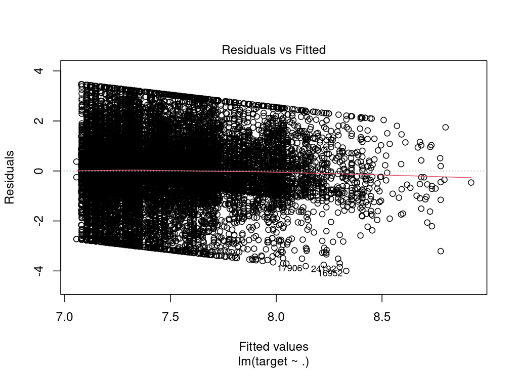

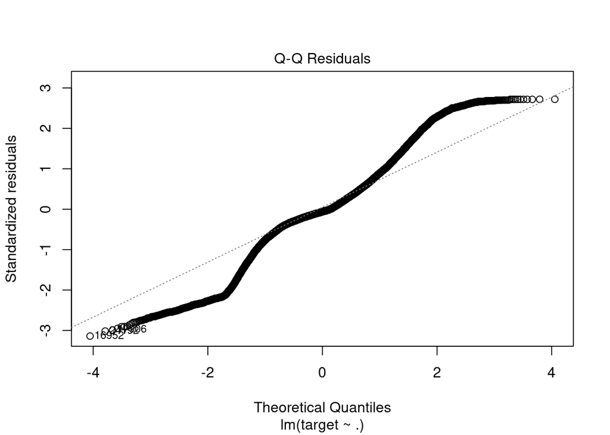

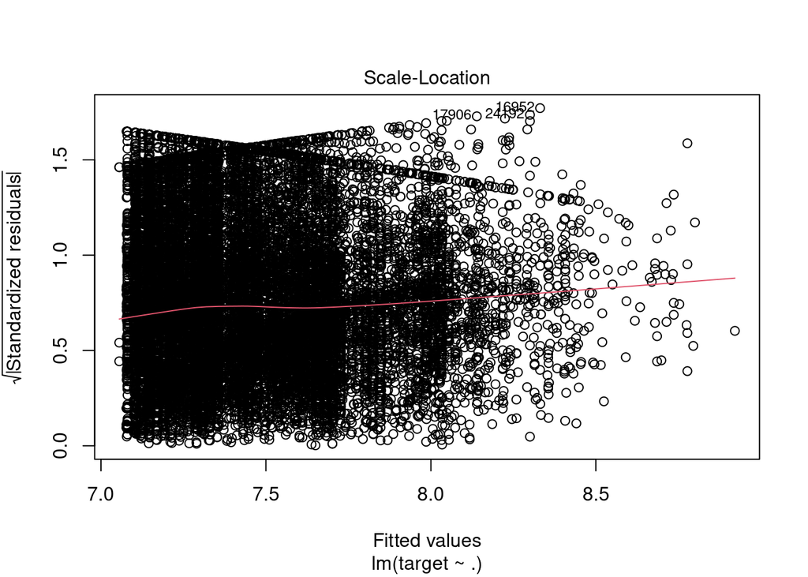

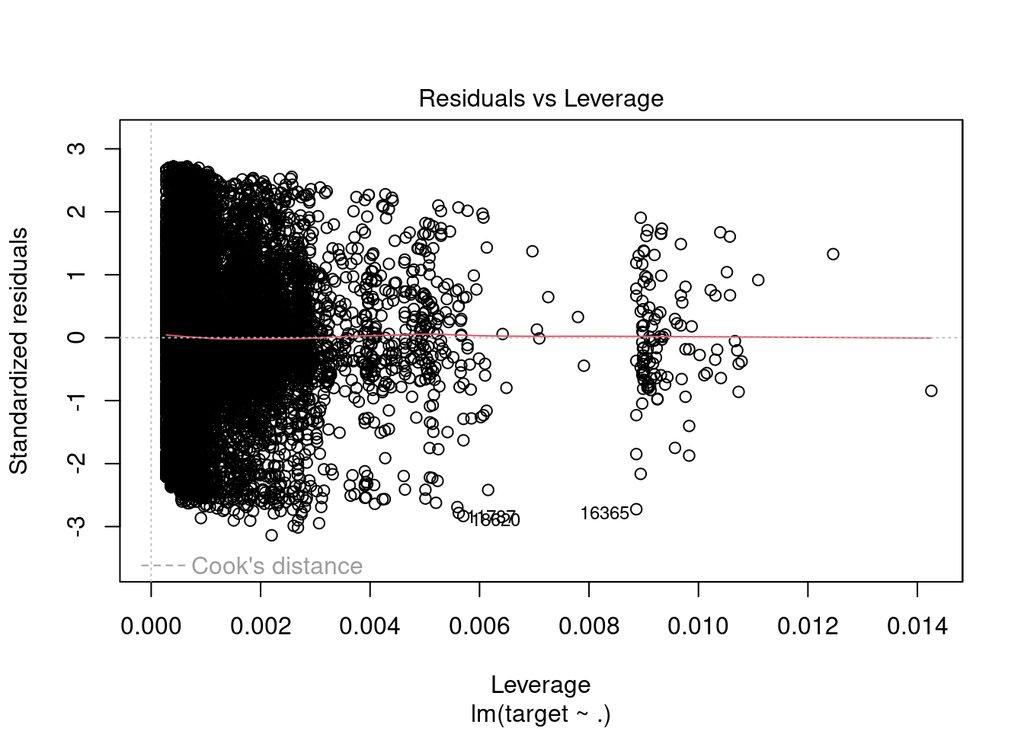

```r
plot(lr_mod)
```

```r
vif(lr_mod)
```

```
                      GVIF Df GVIF^(1/(2*Df))
VehGas            1.043579  1        1.021557
clDensity        11.304255  1        3.362180
clBonusMalus      1.577610  5        1.046646
clDrivAge         8.135073  3        1.418165
clVehPower       12.827548  1        3.581557
clVehAge          1.223795  3        1.034232
clArea           11.419490  1        3.379274
clRegion          1.221660  3        1.033931
clVehBrand        1.301790  1        1.140960
DrivAge_VehPower 17.847035  1        4.224575
```

```r
x <- model.matrix(target ~ ., data = data_sev_cl)[, -1]
y <- data_sev_cl$target
lasso_mod <- cv.glmnet(x, y, alpha = 1)
coef(lasso_mod, s = "lambda.min")
```

```
21 x 1 sparse Matrix of class "dgCMatrix"
                                 s1
(Intercept)              8.22194524
VehGasRegular           -0.05307698
clDensityhigh            0.15234748
clBonusMaluslower        0.14150981
clBonusMalusmedium-low   0.29719432
clBonusMalusmedium-high  0.39721294
clBonusMalushigh         0.70327883
clBonusMalushighest      0.28783759
clDrivAgemedium-low     -0.25109285
clDrivAgemedium-high    -0.37800756
clDrivAgehigh           -0.41111817
clVehPowerhigh           0.15499865
clVehAgemedium-low      -0.32105574
clVehAgemedium-high     -0.33276443
clVehAgehigh            -0.20408080
clAreaDEF               -0.12864780
clRegionCluster2         0.07043136
clRegionCluster3         0.54840091
clRegionCluster4         0.17953557
clVehBrandother         -0.36454402
DrivAge_VehPowerother   -0.15582549
```

Surprisingly, all variables seem to be important following the lasso.

## Additional models

We test additional models using the h2o framework.

```r
# Start h2o
h2o.init()
```

[output not shown]

```r
# Convert dataset into h2o format
train_h2o <- as.h2o(train_data)
test_h2o <- as.h2o(test_data)
# Define target and predictors
target <- "target" # Replace with actual target column name
predictors <- setdiff(names(train_h2o), target) # All columns except target
```

### Random Forest

```r
rf_mod <- h2o.randomForest(
  x = predictors,
  y = target,
  training_frame = train_h2o,
  ntrees = 100,
  max_depth = 20,
  seed = 176
)
```

### Neural Network

```r
# Create validation sample
set.seed(176)
train_index_nn <- createDataPartition(train_data$target, p = 0.8, list = FALSE)
train_data_nn <- train_data[train_index_nn, ]
test_data_nn <- train_data[-train_index_nn, ]
# Train model
nn_mod <- h2o.deeplearning(
  x = predictors,
  y = target,
  training_frame = as.h2o(train_data_nn),
  validation_frame = as.h2o(test_data_nn),
  activation = "RectifierWithDropout",
  hidden = c(50, 50),
  epochs = 100,
  input_dropout_ratio = 0.2,
  l1 = 1e-5,
  l2 = 1e-5,
  stopping_metric = "RMSE",
  stopping_tolerance = 0.001,
  stopping_rounds = 5
)
```

### XGBoost

```r
xgb_mod <- h2o.xgboost(
  x = predictors,
  y = target,
  training_frame = train_h2o,
  ntrees = 100,
  max_depth = 6,
  learn_rate = 0.1,
  seed = 176
)
```

# Model Comparison

As a target metric, we use the root mean squared error (RMSE) since in the insurance context, large errors are more costly than small errors and can even lead to bankruptcy.

```r
# Predictions
lr_pred <- predict(lr_mod, newdata = test_data)
rf_pred <- h2o.predict(rf_mod, newdata = test_h2o)
nn_pred <- h2o.predict(nn_mod, newdata = test_h2o)
xgb_pred <- h2o.predict(xgb_mod, newdata = test_h2o)
# RMSE
rmse_lr <- sqrt(mean((test_data$target - lr_pred)^2))
rmse_rf <- sqrt(mean((test_h2o$target - rf_pred)^2))
rmse_nn <- sqrt(mean((test_h2o$target - nn_pred)^2))
rmse_xgb <- sqrt(mean((test_h2o$target - xgb_pred)^2))
print("RMSE:")
```

```
[1] "RMSE:"
```

```r
print(paste0("Linear Regression: ", rmse_lr))
```

```
[1] "Linear Regression: 1.29110411034871"
```

```r
print(paste0("Random Forest: ", rmse_rf))
```

```
[1] "Random Forest: 1.29503779379226"
```

```r
print(paste0("Neural Network: ", rmse_nn))
```

```
[1] "Neural Network: 1.29501442500071"
```

```r
print(paste0("XGBoost: ", rmse_xgb))
```

```
[1] "XGBoost: 1.29700603843238"
```

```r
# Close h2o cluster
h2o.shutdown(prompt = FALSE)
```

All models show a similar performance. The lowest RMSE is achieved by the linear regression. However, other models could potentially achieve lower RMSEs with hyperparameter tuning. Hence, we choose the XGBoost since it is currently preferred by many data scientists and it is known for its high flexibility and performance.

# Save data

We save the train and test set for later use.

```r
saveRDS(train_data, here::here("data", "edit", "train_data.rds"))
saveRDS(test_data, here::here("data", "edit", "test_data.rds"))
```